# 03_right_tri_complems_deg

## 03_right_tri_complems_deg

#### Question

1. A right triangle is drawn such that its hypotenuse connects the origin to the edge of the unit circle (which is centered at the origin) in the first quadrant. The acute angle at the origin has a measure of 30.9°. What is the measure, in degrees, of the other acute angle of the right triangle?

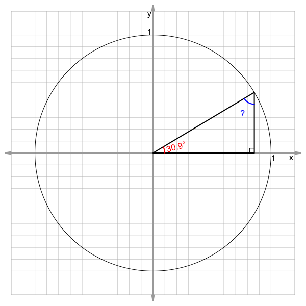

#### Question

2. A right triangle is drawn such that its hypotenuse connects the origin to the edge of the unit circle (which is centered at the origin) in the first quadrant. The acute angle at the origin has a measure of 37.3°. What is the measure, in degrees, of the other acute angle of the right triangle?

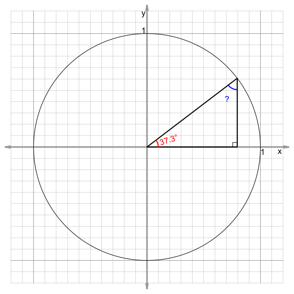

#### Question

3. A right triangle is drawn such that its hypotenuse connects the origin to the edge of the unit circle (which is centered at the origin) in the first quadrant. The acute angle at the origin has a measure of 49.4°. What is the measure, in degrees, of the other acute angle of the right triangle?

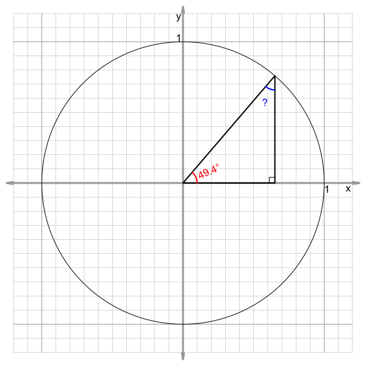

#### Question

4. A right triangle is drawn such that its hypotenuse connects the origin to the edge of the unit circle (which is centered at the origin) in the first quadrant. The acute angle at the origin has a measure of 69.5°. What is the measure, in degrees, of the other acute angle of the right triangle?

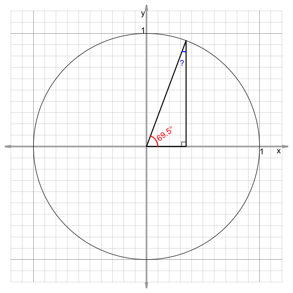

#### Question

5. A right triangle is drawn such that its hypotenuse connects the origin to the edge of the unit circle (which is centered at the origin) in the first quadrant. The acute angle at the origin has a measure of 27.1°. What is the measure, in degrees, of the other acute angle of the right triangle?

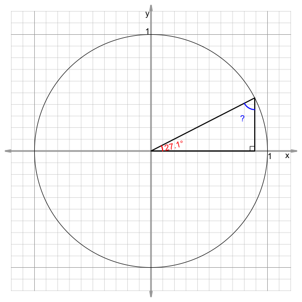

#### Question

6. A right triangle is drawn such that its hypotenuse connects the origin to the edge of the unit circle (which is centered at the origin) in the first quadrant. The acute angle at the origin has a measure of 68.9°. What is the measure, in degrees, of the other acute angle of the right triangle?

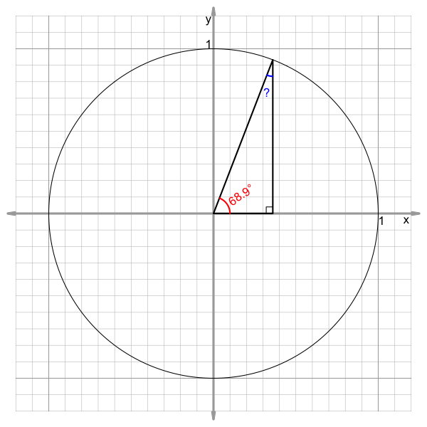

#### Question

7. A right triangle is drawn such that its hypotenuse connects the origin to the edge of the unit circle (which is centered at the origin) in the first quadrant. The acute angle at the origin has a measure of 71.7°. What is the measure, in degrees, of the other acute angle of the right triangle?

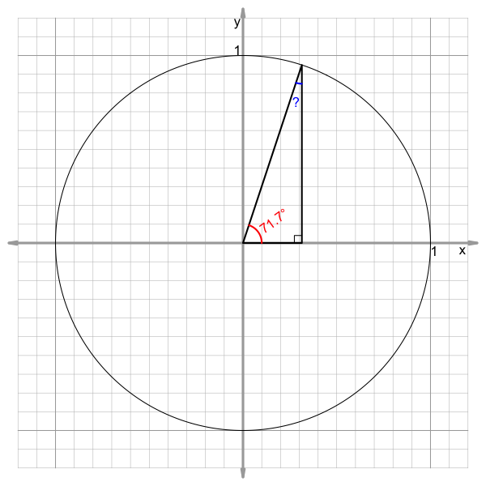

#### Question

8. A right triangle is drawn such that its hypotenuse connects the origin to the edge of the unit circle (which is centered at the origin) in the first quadrant. The acute angle at the origin has a measure of 54.6°. What is the measure, in degrees, of the other acute angle of the right triangle?

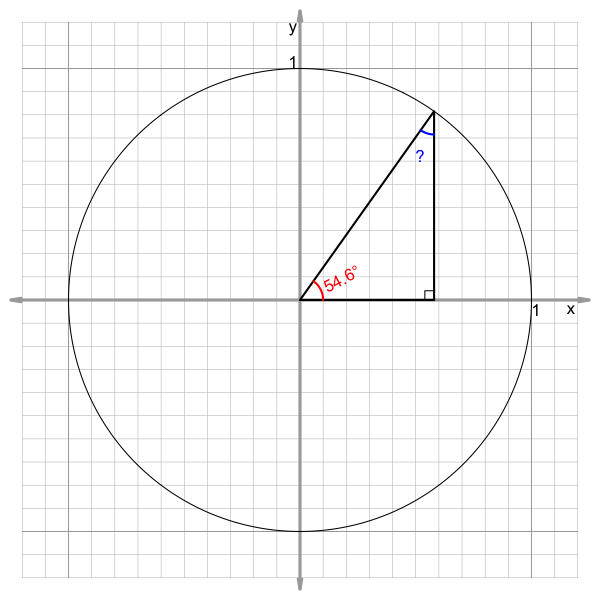